# APG_Pertemuan_5

Riofebri Prasetia (221911192)

3/19/2022

```r
library('MVN')
library('mvoutlier')
library('rcompanion')
library('caret')
library('RVAideMemoire')
library('ellipse')
library('qqplotr')
library('evd')
library('outliers')
library('ggplot2')
library('SciViews')
```

Soal #6.1. Construct and sketch a joint 95% confidence region for the mean difference vector B using the effluent data and results in Example 6.1. Note that the point B == 0 falls outside the 95% contour. Is this result consistent with the test of H0: B == 0 considered in Example 6.1? Explain. BOD_Commercial_lab(xi) SS_Commercial_lab(x2) BOD_Statelabofhygiene(x3) SS_Statelabofhygiene(x4)

```r
url1<-"https://raw.githubusercontent.com/rii92/tugas-APG/main/20%20Maret%202022/APG_dataNo_6.1.csv"
dataeffluent1 <- read.csv(url1)
dataeffluent2 <- data.frame(dataeffluent1$x1j1, dataeffluent1$x1j2, dataeffluent1$x2j1, dataeffluent1$x2j2)
colnames(dataeffluent2)[colnames(dataeffluent2)=="dataeffluent1.x1j1"] <-"x1j1"
colnames(dataeffluent2)[colnames(dataeffluent2)=="dataeffluent1.x1j2"] <-"x1j2"
colnames(dataeffluent2)[colnames(dataeffluent2)=="dataeffluent1.x2j1"] <-"x2j1"
colnames(dataeffluent2)[colnames(dataeffluent2)=="dataeffluent1.x2j2"] <-"x2j2"
dataeffluent2
```

```
##    x1j1 x1j2 x2j1 x2j2
## 1     6   27   25   15
## 2     6   23   28   13
## 3    18   64   36   22
## 4     8   44   35   29
## 5    11   30   15   31
## 6    34   75   44   64
## 7    28   26   42   30
## 8    71  124   54   64
## 9    43   54   34   56
## 10   33   30   29   20
## 11   20   14   39   21
```

```r
dj1 <- dataeffluent1$x1j1-dataeffluent1$x2j1
dj2 <- dataeffluent1$x1j2-dataeffluent1$x2j2
data_dj <- data.frame(dj1, dj2)
data_dj
```

```
##    dj1 dj2
## 1  -19  12
## 2  -22  10
## 3  -18  42
## 4  -27  15
## 5   -4  -1
## 6  -10  11
## 7  -14  -4
## 8   17  60
## 9    9  -2
## 10   4  10
## 11 -19  -7
```

##Membuat Ellipse

```r
mu <- c(0,0)
X <- data_dj
n <- nrow(X)
p <- ncol(X)
xbar <- colMeans(X)
S <- cov(X)
library(car)
```

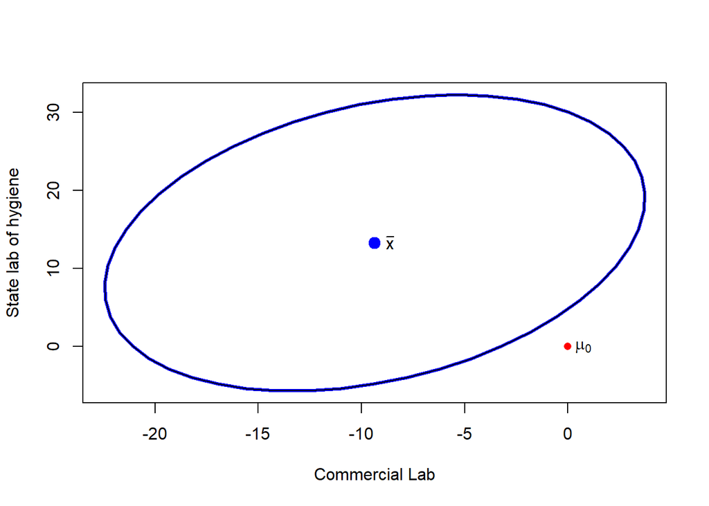

```r
alpha<-0.05
tconst <- sqrt((p/n)*((n-1)/(n-p)) *
                 qf(1-alpha,p,n-p))
id <- c(1,2)
plot(ellipse(center=xbar[id], shape=S[id,id],
             radius=tconst, draw=F),type="n", xlab = "Commercial Lab", ylab = "State lab of hygiene")
lines(ellipse(center=xbar[id], shape=S[id,id],
              radius=tconst, lwd=3))
points(mu[1],mu[2],col="red", pch=16)
text(mu[1]+0.75,mu[2],expression(mu[0]))
text(xbar[1]+0.75,xbar[2],expression(bar(x)))
```

Interpretasi: bisa dilihat bahwa B = (0,0) diluar daerah kepercayaan, dari ini bisa disimpulkan bahwa H0 : d’ = 0 ditolak pada daerah kepercayaan 95%. Sehingga bisa kita simpulkan bahwa hasil data Effluent dengan uji H0 : B = 0 adalah konsisten.

#6.2. Using the information in Example 6.1. construct the 95% Bonferroni simulta neous intervals for the components of the mean difference vector 8. Compare the lengths of these intervals with those of the simultaneous intervals constructed in the example.

##Interval Bonferroni

```r
bon <- NULL
alpha2 <- 1 - 0.05/(2*p)
for(k in 1:p){

 bon <- c(bon,
 xbar[k] - sqrt(S[k,k]/n) * qt(alpha2, df = n-1),
 xbar[k] + sqrt(S[k,k]/n) * qt(alpha2, df = n-1))
}
round(bon, p)
```

```
##    dj1    dj1    dj2    dj2
## -20.57   1.85  -2.97  29.52
```

##Interval Simultan T-square test

```r
library(MVTests)
mu <- c(0, 0)
ujiT <- OneSampleHT2(data = X, mu0 = mu, alpha = 0.05)
summary(ujiT)
```

```
##        One Sample Hotelling T Square Test
##
## Hotelling T Sqaure Statistic = 13.63931
##  F value = 6.138 , df1 = 2 , df2 = 9 , p-value: 0.0208
##
##                    Descriptive Statistics
##
##             dj1      dj2
## N     11.000000 11.00000
## Means -9.363636 13.27273
## Sd    14.115755 20.46016
##
##
##                  Detection important variable(s)
##
##          Lower    Upper Mu0 Important Variables?
## dj1 -22.453272  3.72600   0                FALSE
## dj2  -5.700119 32.24557   0                FALSE
```

Interpretasi: Hasilnya ialah interval T-square test lebih besar di banding interval Bonferroni

#6.3 The data corresponding to sample 8 in Table 6.1 seem unusually large. Remove sample 8. Construct a joint 95% confidence region for the mean difference vector B and the 95% Bonferroni simultaneous intervals for the components of the mean difference vector. Are the results consistent with a test of H0 : B = 0? Discuss. Does the “outlier” make a difference in the analysis of these data?

##Hapus data ke-8

```r
datadj_after_drop <- data_dj[-8,]
datadj_after_drop
```

```
##    dj1 dj2
## 1  -19  12
## 2  -22  10
## 3  -18  42
## 4  -27  15
## 5   -4  -1
## 6  -10  11
## 7  -14  -4
## 9    9  -2
## 10   4  10
## 11 -19  -7
```

##Membuat Ellipse

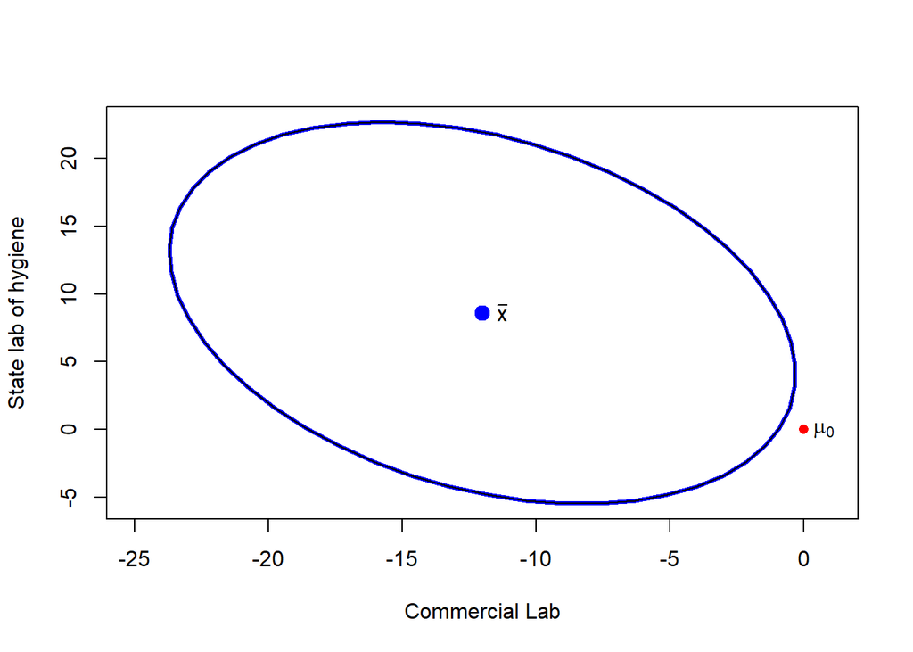

```r
mu <- c(0,0)
X <- datadj_after_drop
n <- nrow(X)
p <- ncol(X)
xbar <- colMeans(X)
S <- cov(X)
library(car)
alpha<-0.05
tconst <- sqrt((p/n)*((n-1)/(n-p)) *
                 qf(1-alpha,p,n-p))
id <- c(1,2)
plot(ellipse(center=xbar[id], shape=S[id,id],
             radius=tconst, draw=F),type="n", xlab = "Commercial Lab", ylab = "State lab of hygiene", xlim = c(-25,1))
lines(ellipse(center=xbar[id], shape=S[id,id],
              radius=tconst, lwd=3))
points(mu[1],mu[2],col="red", pch=16)
text(mu[1]+0.75,mu[2],expression(mu[0]))
text(xbar[1]+0.75,xbar[2],expression(bar(x)))
```

##Interval Bonferroni

```r
bon <- NULL
alpha2 <- 1 - 0.05/(2*p)
for(k in 1:p){

 bon <- c(bon,
 xbar[k] - sqrt(S[k,k]/n) * qt(alpha2, df = n-1),
 xbar[k] + sqrt(S[k,k]/n) * qt(alpha2, df = n-1))
}
round(bon, p)
```

```
##    dj1    dj1    dj2    dj2
## -21.92  -2.08  -3.36  20.56
```

##Interval Simultan T-square test

```r
library(MVTests)
mu <- c(0, 0)
ujiT <- OneSampleHT2(data = X, mu0 = mu, alpha = 0.05)
summary(ujiT)
```

```
##        One Sample Hotelling T Square Test
##
## Hotelling T Sqaure Statistic = 11.44652
##  F value = 5.087 , df1 = 2 , df2 = 8 , p-value: 0.0375
##
##                    Descriptive Statistics
##
##             dj1      dj2
## N      10.00000 10.00000
## Means -12.00000  8.60000
## Sd     11.68094 14.08072
##
##
##                  Detection important variable(s)
##
##          Lower      Upper Mu0 Important Variables?
## dj1 -23.700016 -0.2999837   0               *TRUE*
## dj2  -5.503711 22.7037107   0                FALSE
```

#6.4 Refer to Example 6.1. (a) Redo the analysis in Example 6.1 after transforming the pairs of observations to ln(BOD) and ln(SS). (b) Construct the 95% Bonferroni simultaneous intervals for the components of the mean vector B of transformed variables. (c) Discuss any possible violation of the assumption of a bivariate normal distribution for the difference vectors of transformed observations.

Melakukan transformasi

```r
x1j1_at <- log(dataeffluent1$x1j1)
x1j2_at <- log(dataeffluent1$x1j2)
x2j1_at <- log(dataeffluent1$x2j1)
x2j2_at <- log(dataeffluent1$x2j2)
data_effluent2_at <- data.frame(x1j1_at, x1j2_at, x2j1_at, x2j2_at)
data_effluent2_at
```

```
##     x1j1_at  x1j2_at  x2j1_at  x2j2_at
## 1  1.791759 3.295837 3.218876 2.708050
## 2  1.791759 3.135494 3.332205 2.564949
## 3  2.890372 4.158883 3.583519 3.091042
## 4  2.079442 3.784190 3.555348 3.367296
## 5  2.397895 3.401197 2.708050 3.433987
## 6  3.526361 4.317488 3.784190 4.158883
## 7  3.332205 3.258097 3.737670 3.401197
## 8  4.262680 4.820282 3.988984 4.158883
## 9  3.761200 3.988984 3.526361 4.025352
## 10 3.496508 3.401197 3.367296 2.995732
## 11 2.995732 2.639057 3.663562 3.044522
```

```r
dj1_at <- data_effluent2_at$x1j1_at-data_effluent2_at$x1j2_at
dj2_at <- data_effluent2_at$x2j1_at-data_effluent2_at$x2j2_at
data_dj_at <- data.frame(dj1_at, dj2_at)
data_dj_at
```

```
##         dj1_at     dj2_at
## 1  -1.50407740  0.5108256
## 2  -1.34373475  0.7672552
## 3  -1.26851133  0.4924765
## 4  -1.70474809  0.1880522
## 5  -1.00330211 -0.7259370
## 6  -0.79112759 -0.3746934
## 7   0.07410797  0.3364722
## 8  -0.55760169 -0.1698990
## 9  -0.22778393 -0.4989912
## 10  0.09531018  0.3715636
## 11  0.35667494  0.6190392
```

##Membuat Ellipse

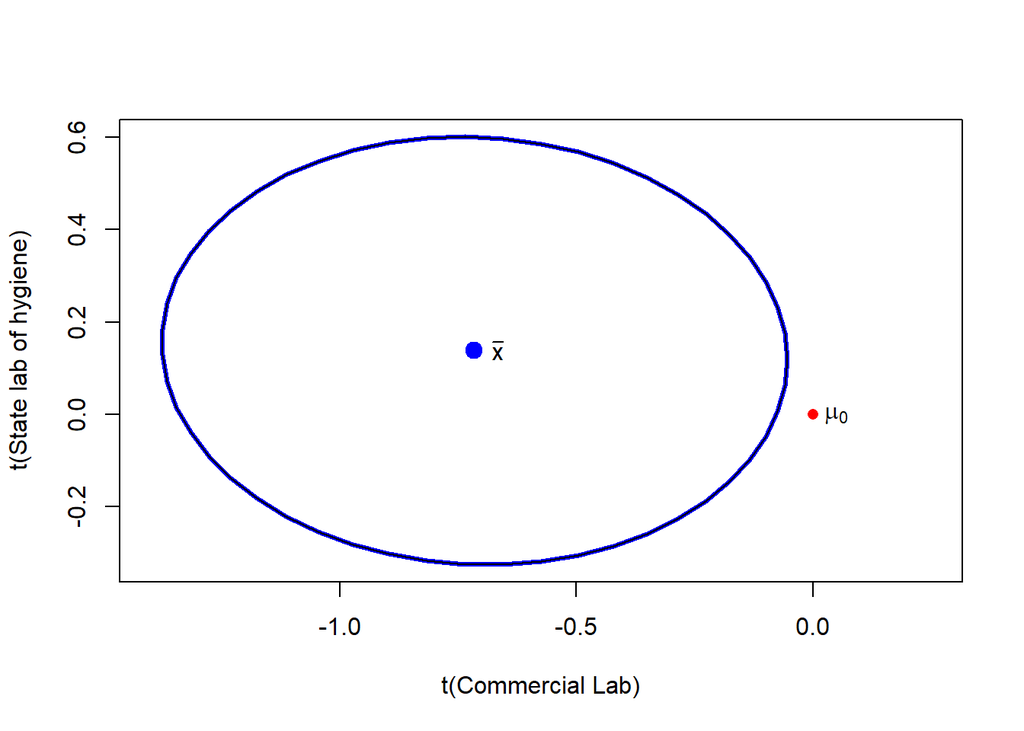

```r
mu <- c(0,0)
X <- data_dj_at
n <- nrow(X)
p <- ncol(X)
xbar <- colMeans(X)
S <- cov(X)
library(car)
alpha<-0.05
tconst <- sqrt((p/n)*((n-1)/(n-p)) *
                 qf(1-alpha,p,n-p))
id <- c(1,2)
plot(ellipse(center=xbar[id], shape=S[id,id],
             radius=tconst, draw=F),type="n", xlab = "t(Commercial Lab)", ylab = "t(State lab of hygiene)", xlim = c(-1.4,0.25))
lines(ellipse(center=xbar[id], shape=S[id,id],
              radius=tconst, lwd=3))
points(mu[1],mu[2],col="red", pch=16)
text(mu[1]+0.05,mu[2],expression(mu[0]))
text(xbar[1]+0.05,xbar[2],expression(bar(x)))
```

Interpretasi: Hasilnya menunjukkan bahwa setelah dilakukan transformasi ln atau log(BOD) dan ln(SS), titik B = 0 berada di luar penerimaan H0. Maka data Effluent setelah transformasi ln konsisten dengan uji H0: B = 0.

##Interval Bonferroni

```r
bon <- NULL
alpha2 <- 1 - 0.05/(2*p)
for(k in 1:p){

 bon <- c(bon,
 xbar[k] - sqrt(S[k,k]/n) * qt(alpha2, df = n-1),
 xbar[k] + sqrt(S[k,k]/n) * qt(alpha2, df = n-1))
}
round(bon, p)
```

```
## dj1_at dj1_at dj2_at dj2_at
##  -1.28  -0.15  -0.26   0.53
```

##Interval Simultan T-square test

```r
library(MVTests)
mu <- c(0, 0)
ujiT <- OneSampleHT2(data = X, mu0 = mu, alpha = 0.05)
summary(ujiT)
```

```
##        One Sample Hotelling T Square Test
##
## Hotelling T Sqaure Statistic = 11.69952
##  F value = 5.265 , df1 = 2 , df2 = 9 , p-value: 0.0306
##
##                    Descriptive Statistics
##
##           dj1_at     dj2_at
## N     11.0000000 11.0000000
## Means -0.7158903  0.1378331
## Sd     0.7129352  0.4998262
##
##
##                  Detection important variable(s)
##
##             Lower       Upper Mu0 Important Variables?
## dj1_at -1.3770000 -0.05478066   0               *TRUE*
## dj2_at -0.3256592  0.60132535   0                FALSE
```

Interpretasi: Interval kepercayaan T-square masih lebih luas di banding interval bonferroni.

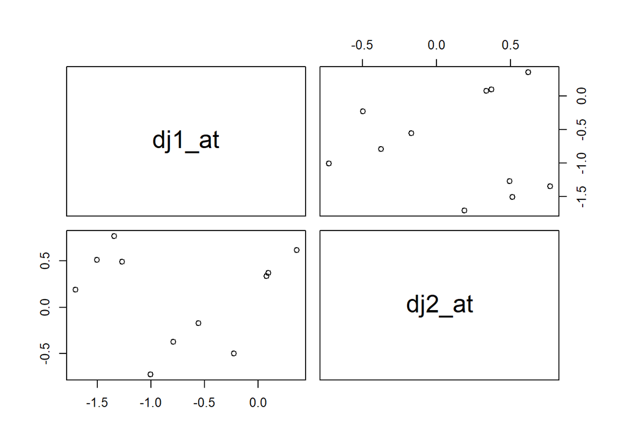

```r
pairs(data_dj_at)
```

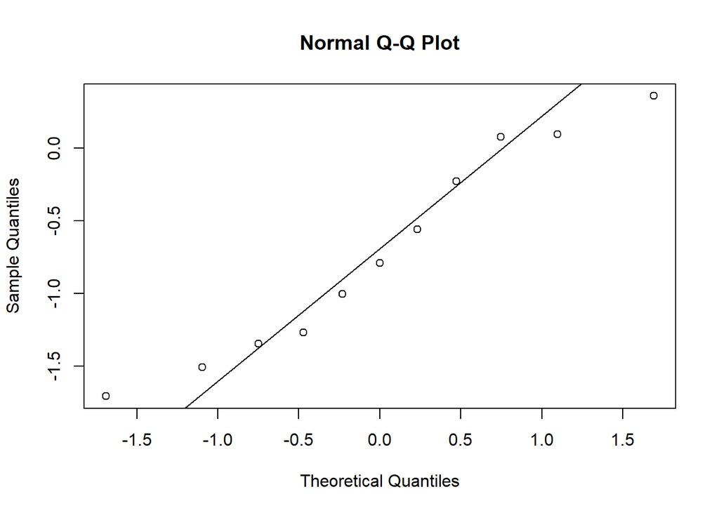

```r
qqnorm(data_dj_at$dj1_at)
qqline(data_dj_at$dj1_at)
```

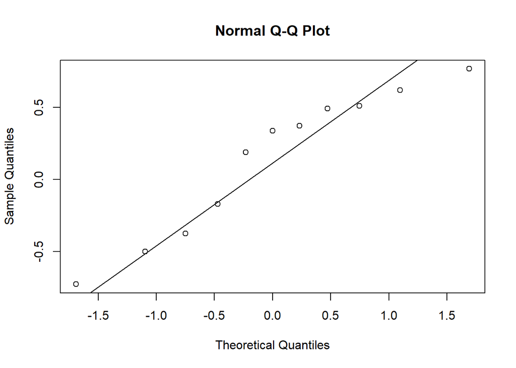

```r
qqnorm(data_dj_at$dj2_at)
qqline(data_dj_at$dj2_at)
```

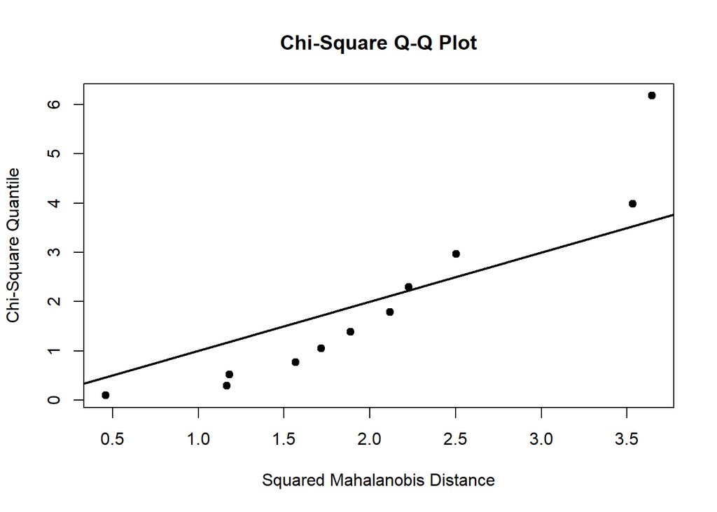

```r
mvn(data_dj_at, multivariatePlot = "qq", showOutliers = TRUE)[4]
```

```r
mvn(data = data_dj_at[, c(1,2)], multivariatePlot = 'plot', showOutlier
= TRUE)
```

```
## $multivariateNormality
##            Test        HZ    p value MVN
## 1 Henze-Zirkler 0.5650424 0.09061148 YES
##
## $univariateNormality
##               Test  Variable Statistic   p value Normality
## 1 Anderson-Darling  dj1_at      0.2783    0.5756    YES
## 2 Anderson-Darling  dj2_at      0.4235    0.2609    YES
##
## $Descriptives
##         n       Mean   Std.Dev     Median       Min       Max       25th
## dj1_at 11 -0.7158903 0.7129352 -0.7911276 -1.704748 0.3566749 -1.3061230
## dj2_at 11  0.1378331 0.4998262  0.3364722 -0.725937 0.7672552 -0.2722962
##               75th       Skew  Kurtosis
## dj1_at -0.07683798  0.1214125 -1.662489
## dj2_at  0.50165105 -0.4284293 -1.471484
##
## $multivariateOutliers
## NULL
```

```r
mshapiro.test(data_dj_at[, c(1,2)])
```

```
##
##  Multivariate Shapiro-Wilk normality test
##
## data:  (dj1_at,dj2_at)
## W = 0.91655, p-value = 0.2909
```

Interpretasi: Pada test Multivariate normal Henze-Zirkler dan shapiro wilk menyatakan bahwa data multivariate/bivariate normal. Akan tetapi ketika melihat plot bivariate, sebaran data nya tidak terlihat pola arahnya. Demikian itu bisa disimpulkan belum cukup bukti untuk menyatakan bahwa data effluent setelah transformasi melanggar asumsi distribusi normal

#6.17 The data in Table 6.8 were collected to test two psychological models of numerical cognition. Does the processing of numbers depend on the way the numbers are presented (words, Arabic digits)? Thirty-two subjects were required to make a series of quick numerical judgments about two numbers presented as either two number words (“two,” “four”) or two single Arabic digits (“2,” “4”). The subjects were asked to respond “same” if the two numbers had the same numerical parity (both even or both odd) and “different” if the two numbers had a different parity (one even, one odd). Half of the subjects were assigned a block of Arabic digit trials, followed by a block of number word trials, and half of the subjects received the blocks of trials in the reverse order. Within each block, the order of “same” and “different” parity trials was randomized for each subject. For each of the four combinations of parity and format, the median reaction times for correct responses were recorded for each subject. Here X1 = median reaction time for word format-different parity combination X2 = median reaction time for word format-same parity combination X3 = median reaction time for Arabic format-different parity combination X4 = median reaction time for Arabic format-same parity combination

1. Test for treatment effects using a repeated measures design. Set a = .05.
2. Construct 95% (simultaneous) confidence intervals for the contrasts representing the number format effect, the parity type effect and the interaction effect. Interpret the resulting intervals.
3. The absence of interaction supports the M model of numerical cognition, while the presence of interaction supports the C and C model of numerical cognition. Which model is supported in this experiment?
4. For each subject, construct three difference scores corresponding to the number format contrast, the parity type contrast, and the interaction

contrast. Is a multivariate normal distribution a reasonable population model for these data? Explain

```r
url <- "https://raw.githubusercontent.com/rii92/tugas-APG/main/20%20Maret%202022/APG_dataNo_6.17.csv"
datasoal_5 <- read.csv(url)
datasoal_5
```

```
##        xi     x2     x3    x4
## 1   869.0  860.5  691.0 601.0
## 2   995.0  875.0  678.0 659.0
## 3  1056.0  930.5  833.0 826.0
## 4  1126.0  954.0  888.0 728.0
## 5  1044.0  909.0  865.0 839.0
## 6   925.0  856.5 1059.5 797.0
## 7  1172.5  896.5  926.0 766.0
## 8  1408.5 1311.0  854.0 986.0
## 9  1028.0  887.0  915.0 735.0
## 10 1011.0  863.0  761.0 657.0
## 11  726.0  674.0  663.0 583.0
## 12  982.0  894.0  831.0 640.0
## 13 1225.0 1179.0 1037.0 905.5
## 14  731.0  662.0  662.5 624.0
```

[output cut: 18 more lines]

```r
Cmat <- matrix(c(
 -1, 1, -1, 1,
 -1, -1, 1, 1,
 -1, 1, 1, -1
), byrow = TRUE, nrow = 3)
Cmat
```

```
##      [,1] [,2] [,3] [,4]
## [1,]   -1    1   -1    1
## [2,]   -1   -1    1    1
## [3,]   -1    1    1   -1
```

```r
T.test <- function(X, Cmu){
 X <- as.matrix(X)
 n <- nrow(X)
 p <- ncol(X)
 df2 <- n-p
 xbar <- colMeans(X)
 S <- cov(X)
 alpha <- 0.05
 if(df2 < 1L) stop("Need nrow(X) > ncol(X).")
 if(length(Cmu) != p) mu <- rep(Cmu[1], p)

 T2 <- n * t((Cmat %*% xbar) - Cmu) %*%
 solve(Cmat %*% S %*% t(Cmat)) %*%
 ((Cmat %*% xbar) - Cmu)

 Fstat <- T2 / ((p-1) * (n-1) / df2)
 Fcalc <- qf(1-alpha, df1 = p-1, df2 = n-p+1) * (n - 1) * (p - 1) / (n-p+1)

 pval <- 1 - pf(Fstat, df1 = p-1, df2 = df2)

 data.frame(T2 = as.numeric(T2),
 Fstat = as.numeric(Fstat),
 Fcalc = as.numeric(Fcalc),
 df1 = p-1,
 df2 = df2,
 p.value = as.numeric(pval),
 row.names="") }
```

```r
Cmu <- c(0, 0, 0)
T.test(datasoal_5, Cmu)
```

```
##        T2    Fstat   Fcalc df1 df2      p.value
##  153.7275 46.28355 9.40913   3  28 5.591205e-11
```

Interpretasi: Karena T2 > F hitung dan p-value < alpha=0.05. Maka dari ini bisa disimpulkan bahwa tolak H0 dimana cmu = 0. Dengan tingkat signifikansi 5%, dapat di simpulkan bahwa dari data terdapat minimal 1 perbedaan nilai cmiu pada hasil test 2 model psikologi kemampuan numerik

```r
C1 <- matrix(Cmat[1,], ncol = 1)
C2 <- matrix(Cmat[2,], ncol = 1)
C3 <- matrix(Cmat[3,], ncol = 1)

S.ci <- function(data, c, n, level = 0.95){
  q <- length(c)
  xbar <- colMeans(data)
  S <- cov(data)
  if(nrow(S) != q) stop("Need length(c) == nrow(S)")
  if(ncol(S) != q) stop("Need length(c) == ncol(S).")
  if(level <=0 | level >= 1) stop("Need 0 < level < 1.")

  cval <- qf(level, q-1, n-q+1) * (q-1) * (n-1) / (n-q+1)

  # hitung z bar
  zhat <- t(c) %*% xbar

  # hitung varians z
  zvar <- (t(c) %*% S %*% c) / n

  # hitung standard error
  const <- sqrt(cval * zvar)

  # Membuat Smultaneous COnfidence Interval
  c(lower = zhat - const, upper = zhat + const)
}

print(paste("CI untuk single contrast yang mewakili efek paritas"))
```

```
## [1] "CI untuk single contrast yang mewakili efek paritas"
```

```r
S.ci(datasoal_5, C1, n)
```

```
##      lower      upper
## -371.06506  -41.59119
```

```r
print(paste("CI untuk single contrast yang mewakili efek format"))
```

```
## [1] "CI untuk single contrast yang mewakili efek format"
```

```r
S.ci(datasoal_5, C2, n)
```

```
##      lower      upper
## -543.18700  -70.65675
```

```r
print(paste("CI untuk single contrast yang mewakili efek interaksi"))
```

```
## [1] "CI untuk single contrast yang mewakili efek interaksi"
```

```r
S.ci(datasoal_5, C3, n)
```

```
##     lower     upper
## -95.35824 140.20199
```

Interpretasi: 1. Pada CI untuk single contrast yang mewakili efek paritas, tidak mengandung 0 yang artinya kesamaan paritas membutuhkan sedikit waktu untuk di jawab 2. Pada CI untuk single contrast yang mewakili efek format, tidak mengandung 0 yang artinya format arab membutuhkan sedikit waktu untuk di jawab 3. Pada CI untuk single contrast yang mewakili efek interaksi, mengandung 0 yang artinya tidak terdapat efek interaksi

Diketahui: 1. Model M: Ketiadaan interaksi 2. Model C: Kehadiran interaksi Dapat dilihat pada hasil CI single contrast yang mewakili efek interaksi hasil nya mengansung 0. Artinya tidak terdapat efek interaksi. Oleh karena itu, ketiadaan interaksi itu mendukung model kognisi numerik M.

```r
#ubah data jadi matrix
matrix_data <- as.matrix(datasoal_5)
matrix_data
```

```
##           xi     x2     x3    x4
##  [1,]  869.0  860.5  691.0 601.0
##  [2,]  995.0  875.0  678.0 659.0
##  [3,] 1056.0  930.5  833.0 826.0
##  [4,] 1126.0  954.0  888.0 728.0
##  [5,] 1044.0  909.0  865.0 839.0
##  [6,]  925.0  856.5 1059.5 797.0
##  [7,] 1172.5  896.5  926.0 766.0
##  [8,] 1408.5 1311.0  854.0 986.0
##  [9,] 1028.0  887.0  915.0 735.0
## [10,] 1011.0  863.0  761.0 657.0
## [11,]  726.0  674.0  663.0 583.0
## [12,]  982.0  894.0  831.0 640.0
## [13,] 1225.0 1179.0 1037.0 905.5
## [14,]  731.0  662.0  662.5 624.0
```

[output cut: 18 more lines]

```r
# Difference score from the parity type contrast
diff_parity <- matrix_data %*% C1

# Difference score from the number type contrast
diff_format <- matrix_data %*% C2

# Difference score from the interaction type contrast
diff_interaction <- matrix_data %*% C3

diff_data <- data.frame(diff_parity, diff_format, diff_interaction)
diff_data
```

```
##    diff_parity diff_format diff_interaction
## 1        -98.5      -437.5             81.5
## 2       -139.0      -533.0           -101.0
## 3       -132.5      -327.5           -118.5
## 4       -332.0      -464.0            -12.0
## 5       -161.0      -249.0           -109.0
## 6       -331.0        75.0            194.0
## 7       -436.0      -377.0           -116.0
## 8         34.5      -879.5           -229.5
## 9       -321.0      -265.0             39.0
## 10      -252.0      -456.0            -44.0
## 11      -132.0      -154.0             28.0
## 12      -279.0      -405.0            103.0
## 13      -177.5      -461.5             85.5
## 14      -107.5      -106.5            -30.5
```

[output cut: 18 more lines]

Cek Multivariate Normal

```r
mvn(data = diff_data[, c(1,2,3)], multivariatePlot = 'plot', showOutliers = TRUE)
```

```
## $multivariateNormality
##            Test      HZ    p value MVN
## 1 Henze-Zirkler 1.02264 0.01106792  NO
##
## $univariateNormality
##               Test         Variable Statistic   p value Normality
## 1 Anderson-Darling   diff_parity       0.7629    0.0423    NO
## 2 Anderson-Darling   diff_format       0.3966    0.3496    YES
## 3 Anderson-Darling diff_interaction    0.4373    0.2783    YES
##
## $Descriptives
##                   n       Mean  Std.Dev  Median    Min   Max     25th    75th
## diff_parity      32 -206.32812 139.9195 -169.25 -607.0  34.5 -283.375 -121.25
## diff_format      32 -306.92188 200.6721 -276.75 -879.5  75.0 -438.500 -192.25
## diff_interaction 32   22.42188 100.0367   37.50 -229.5 217.0  -29.750   82.50
##                        Skew   Kurtosis
## diff_parity      -0.8980471  0.6024854
## diff_format      -0.6150826  0.6810366
## diff_interaction -0.3086301 -0.0977505
##
## $multivariateOutliers
## NULL
```

```r
mshapiro.test(diff_data)
```

```
##
##  Multivariate Shapiro-Wilk normality test
##
## data:  (diff_parity,diff_format,diff_interaction)
## W = 0.86793, p-value = 0.00104
```

Cek outlier

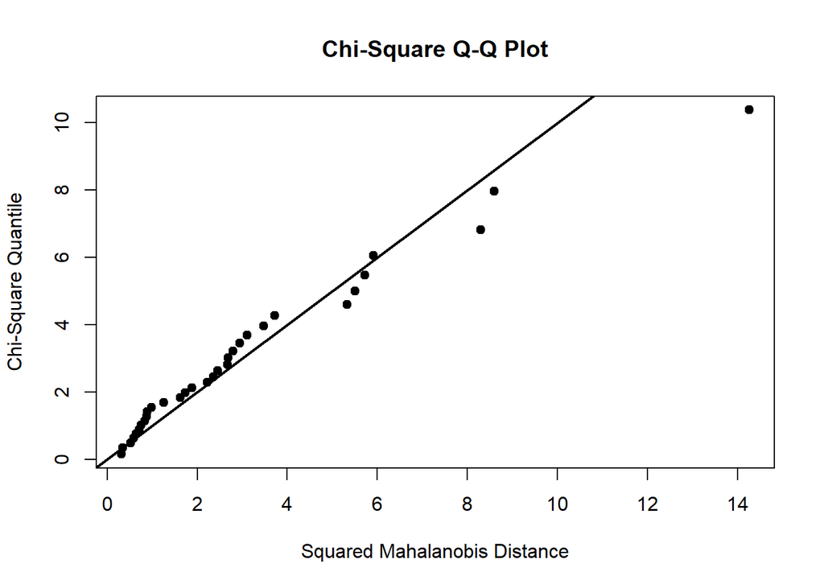

```
## $multivariateNormality
##            Test      HZ    p value MVN
## 1 Henze-Zirkler 1.02264 0.01106792  NO
##
## $univariateNormality
##               Test         Variable Statistic   p value Normality
## 1 Anderson-Darling   diff_parity       0.7629    0.0423    NO
## 2 Anderson-Darling   diff_format       0.3966    0.3496    YES
## 3 Anderson-Darling diff_interaction    0.4373    0.2783    YES
##
## $Descriptives
##                   n       Mean  Std.Dev  Median    Min   Max     25th    75th
## diff_parity      32 -206.32812 139.9195 -169.25 -607.0  34.5 -283.375 -121.25
## diff_format      32 -306.92188 200.6721 -276.75 -879.5  75.0 -438.500 -192.25
## diff_interaction 32   22.42188 100.0367   37.50 -229.5 217.0  -29.750   82.50
##                        Skew   Kurtosis
## diff_parity      -0.8980471  0.6024854
## diff_format      -0.6150826  0.6810366
## diff_interaction -0.3086301 -0.0977505
##
## $multivariateOutliers
## NULL
```

```r
mvn(diff_data, multivariatePlot = "qq", showOutliers = TRUE)
```

Interpretasi: Berdasarkan hasil dengan metode Henze-Zirkler dan shapiro wilk bahwa data tidak multivariate normal